# Ejemplo Tyrell Corp 1: Análisis de Crecimiento de Replicantes Nexus-4

Regresiones no lineales - Modelo Logístico

Javi Cantón-Correa

[figure not shown]

## 1. Introducción

En este análisis, como parte del departamento de investigación de Tyrell Corporation, estudiamos el comportamiento de una población de replicantes Nexus-4 en un módulo de privación sensorial. Este estudio es crucial para entender los patrones de adaptación y crecimiento de nuestros modelos más avanzados en entornos controlados.

## 2. Simulación del escenario experimental

En nuestro laboratorio de Los Ángeles, hemos observado el crecimiento del número de replicantes funcionando en un entorno cerrado. La evolución muestra un patrón de saturación, un comportamiento típicamente no lineal que refleja las limitaciones del entorno y la capacidad de adaptación de los replicantes.

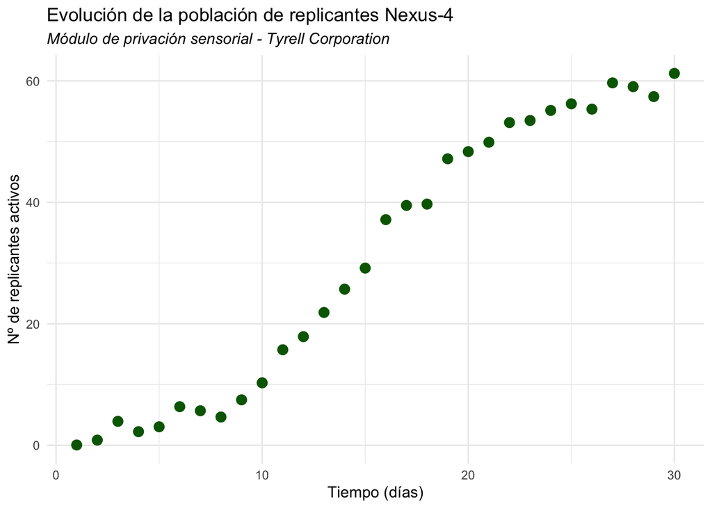

```r
set.seed(123)
tiempo <- 1:30
# Generamos datos con forma logística + ruido
replicantes <- 60 / (1 + exp(-0.3 * (tiempo - 15))) + rnorm(30, mean = 0, sd = 1.5)

# Representación de los datos
ggplot(data.frame(tiempo, replicantes), aes(x = tiempo, y = replicantes)) +
  geom_point(color = "darkgreen", size = 3) +
  labs(title = "Evolución de la población de replicantes Nexus-4",
       subtitle = "Módulo de privación sensorial - Tyrell Corporation",
       x = "Tiempo (días)",
       y = "Nº de replicantes activos") +
  theme_minimal() +
  theme(plot.subtitle = element_text(face = "italic"))
```

## 3. Análisis inicial con regresión lineal

Como primer enfoque, intentamos modelar el crecimiento con una regresión lineal, similar a nuestros análisis previos en otras instalaciones de Tyrell Corporation.

```r
modelo_lineal <- lm(replicantes ~ tiempo)
summary(modelo_lineal)
```

```
##
## Call:
## lm(formula = replicantes ~ tiempo)
##
## Residuals:
##     Min      1Q  Median      3Q     Max
## -7.4309 -3.7264 -0.3012  4.2624  7.4696
##
## Coefficients:
##             Estimate Std. Error t value Pr(>|t|)
## (Intercept) -8.00437    1.75913   -4.55 9.48e-05 ***
## tiempo       2.51044    0.09909   25.34  < 2e-16 ***
## ---
## Signif. codes:  0 '***' 0.001 '**' 0.01 '*' 0.05 '.' 0.1 ' ' 1
##
## Residual standard error: 4.698 on 28 degrees of freedom
## Multiple R-squared:  0.9582, Adjusted R-squared:  0.9567
## F-statistic: 641.9 on 1 and 28 DF,  p-value: < 2.2e-16
```

```r
# Interpretación de métricas
cat("\nInterpretación del modelo lineal:\n")
```

```
##
## Interpretación del modelo lineal:
```

```r
cat("R² =", round(summary(modelo_lineal)$r.squared, 3), "\n")
```

```
## R² = 0.958
```

```r
cat("R² ajustado =", round(summary(modelo_lineal)$adj.r.squared, 3), "\n")
```

```
## R² ajustado = 0.957
```

```r
cat("Error estándar residual =", round(summary(modelo_lineal)$sigma, 3), "\n")
```

```
## Error estándar residual = 4.698
```

```r
cat("F-statistic =", round(summary(modelo_lineal)$fstatistic[1], 3), "\n")
```

```
## F-statistic = 641.861
```

```r
cat("p-value =", format.pval(pf(summary(modelo_lineal)$fstatistic[1],
                               summary(modelo_lineal)$fstatistic[2],
                               summary(modelo_lineal)$fstatistic[3],
                               lower.tail = FALSE), digits = 3), "\n")
```

```
## p-value = <2e-16
```

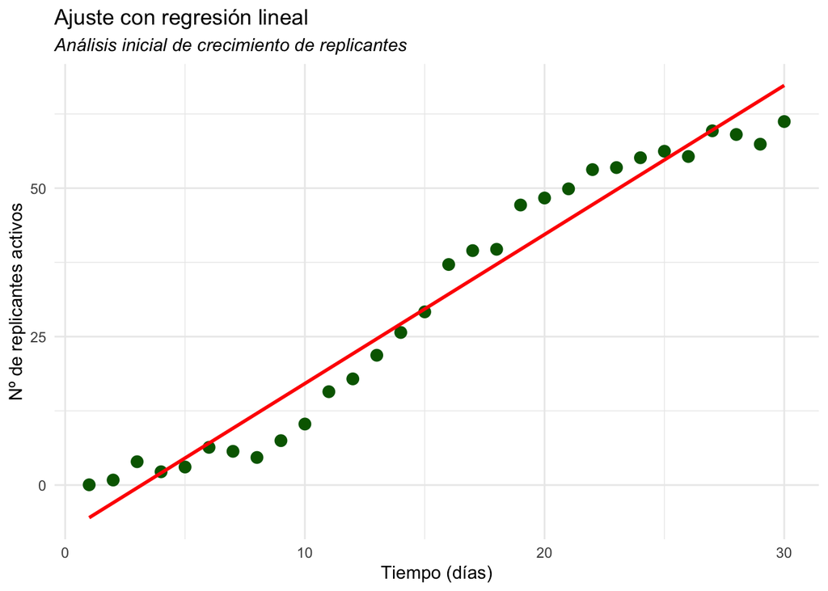

```r
# Visualización del modelo lineal
ggplot(data.frame(tiempo, replicantes), aes(x = tiempo, y = replicantes)) +
  geom_point(color = "darkgreen", size = 3) +
  geom_smooth(method = "lm", color = "red", se = FALSE) +
  labs(title = "Ajuste con regresión lineal",
       subtitle = "Análisis inicial de crecimiento de replicantes",
       x = "Tiempo (días)",
       y = "Nº de replicantes activos") +
  theme_minimal() +
  theme(plot.subtitle = element_text(face = "italic"))
```

> **Interpretación de métricas**: - El R² de 0.958 indica que el modelo lineal explica el 95.8% de la variabilidad en los datos - El error estándar residual de 4.698 sugiere una desviación promedio significativa de los valores predichos - Aunque el F-statistic es significativo (p < 0.001), esto solo indica que hay una relación, no que sea lineal - Los residuales muestran un patrón sistemático, indicando que el modelo lineal no captura la estructura de los datos

> **Explicación matemática**: El modelo lineal asume un crecimiento constante, siguiendo la ecuación:
> $$y = a + b \cdot t$$

> **Explicación intuitiva**: Imagina que cada día llega un número fijo de nuevos replicantes al módulo, como si fuera una línea de producción constante. Este modelo es como una máquina que produce siempre la misma cantidad, sin importar cuántos replicantes haya ya en el módulo. Es demasiado simple para capturar la realidad, donde el crecimiento se ralentiza cuando el espacio se llena.

## 4. Ajuste con regresión polinómica de grado 2

Basándonos en nuestros estudios previos en Londres, donde implementamos modelos polinomiales, probamos este enfoque para el módulo de privación sensorial.

```r
modelo_poly2 <- lm(replicantes ~ poly(tiempo, 2, raw = TRUE))
summary(modelo_poly2)
```

```
##
## Call:
## lm(formula = replicantes ~ poly(tiempo, 2, raw = TRUE))
##
## Residuals:
##     Min      1Q  Median      3Q     Max
## -7.5939 -3.7749 -0.0946  4.2939  6.9224
##
## Coefficients:
##                               Estimate Std. Error t value Pr(>|t|)
## (Intercept)                  -9.448061   2.781811  -3.396  0.00213 **
## poly(tiempo, 2, raw = TRUE)1  2.781126   0.413662   6.723 3.22e-07 ***
## poly(tiempo, 2, raw = TRUE)2 -0.008732   0.012948  -0.674  0.50579
## ---
## Signif. codes:  0 '***' 0.001 '**' 0.01 '*' 0.05 '.' 0.1 ' ' 1
##
## Residual standard error: 4.744 on 27 degrees of freedom
## Multiple R-squared:  0.9589, Adjusted R-squared:  0.9558
## F-statistic: 314.9 on 2 and 27 DF,  p-value: < 2.2e-16
```

```r
# Interpretación de métricas
cat("\nInterpretación del modelo polinomial de grado 2:\n")
```

```
##
## Interpretación del modelo polinomial de grado 2:
```

```r
cat("R² =", round(summary(modelo_poly2)$r.squared, 3), "\n")
```

```
## R² = 0.959
```

```r
cat("R² ajustado =", round(summary(modelo_poly2)$adj.r.squared, 3), "\n")
```

```
## R² ajustado = 0.956
```

```r
cat("Error estándar residual =", round(summary(modelo_poly2)$sigma, 3), "\n")
```

```
## Error estándar residual = 4.744
```

```r
cat("F-statistic =", round(summary(modelo_poly2)$fstatistic[1], 3), "\n")
```

```
## F-statistic = 314.909
```

```r
cat("p-value =", format.pval(pf(summary(modelo_poly2)$fstatistic[1],
                               summary(modelo_poly2)$fstatistic[2],
                               summary(modelo_poly2)$fstatistic[3],
                               lower.tail = FALSE), digits = 3), "\n")
```

```
## p-value = <2e-16
```

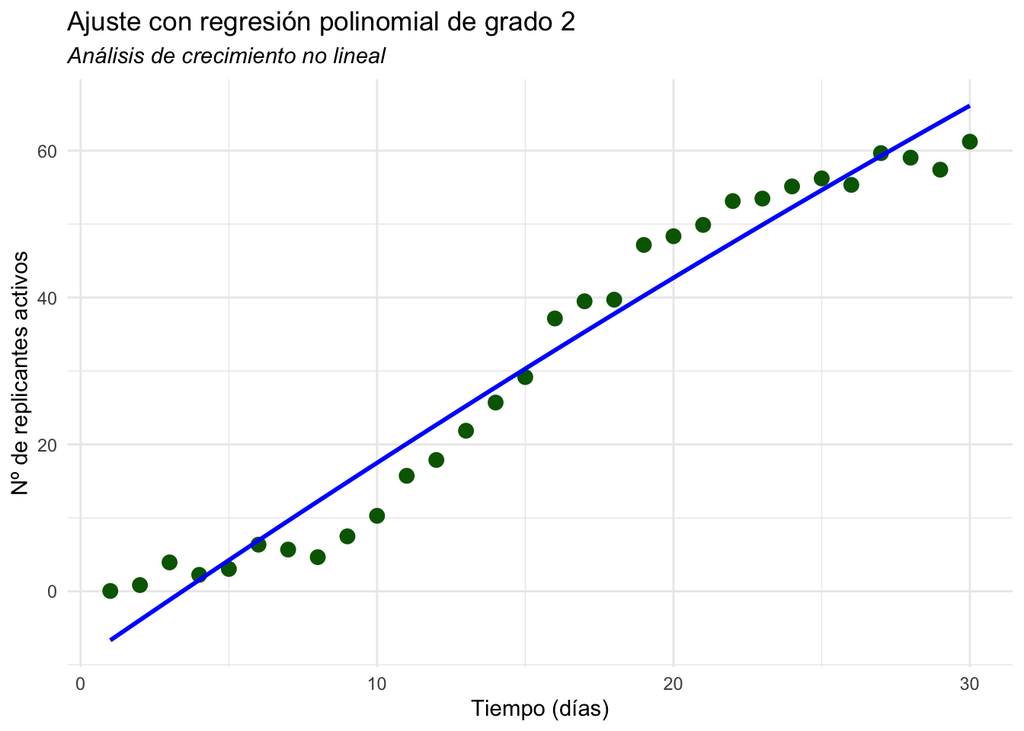

```r
# Visualización del modelo polinomial de grado 2
ggplot(data.frame(tiempo, replicantes), aes(x = tiempo, y = replicantes)) +
  geom_point(color = "darkgreen", size = 3) +
  geom_smooth(method = "lm", formula = y ~ poly(x, 2), color = "blue", se = FALSE) +
  labs(title = "Ajuste con regresión polinomial de grado 2",
       subtitle = "Análisis de crecimiento no lineal",
       x = "Tiempo (días)",
       y = "Nº de replicantes activos") +
  theme_minimal() +
  theme(plot.subtitle = element_text(face = "italic"))
```

> **Explicación matemática**: El modelo polinomial de grado 2 introduce curvatura mediante:
> $$y =
> a + b \cdot t + c \cdot t^2$$

## 5. Ajuste con regresión polinómica de grado 3

Como extensión de nuestros estudios en Londres, implementamos un modelo polinomial de grado 3 para capturar mejor la complejidad del crecimiento de los replicantes Nexus-4.

```r
modelo_poly3 <- lm(replicantes ~ poly(tiempo, 3, raw = TRUE))
summary(modelo_poly3)
```

```
##
## Call:
## lm(formula = replicantes ~ poly(tiempo, 3, raw = TRUE))
##
## Residuals:
##     Min      1Q  Median      3Q     Max
## -3.6605 -1.3558 -0.3679  0.9020  3.8138
##
## Coefficients:
##                                Estimate Std. Error t value Pr(>|t|)
## (Intercept)                   3.5710851  1.7960640   1.988 0.057404 .
## poly(tiempo, 3, raw = TRUE)1 -1.8807270  0.4935591  -3.811 0.000765 ***
## poly(tiempo, 3, raw = TRUE)2  0.3611301  0.0366748   9.847 2.92e-10 ***
## poly(tiempo, 3, raw = TRUE)3 -0.0079540  0.0007785 -10.218 1.35e-10 ***
## ---
## Signif. codes:  0 '***' 0.001 '**' 0.01 '*' 0.05 '.' 0.1 ' ' 1
##
## Residual standard error: 2.159 on 26 degrees of freedom
## Multiple R-squared:  0.9918, Adjusted R-squared:  0.9909
## F-statistic:  1049 on 3 and 26 DF,  p-value: < 2.2e-16
```

```r
# Interpretación de métricas
cat("\nInterpretación del modelo polinomial de grado 3:\n")
```

```
##
## Interpretación del modelo polinomial de grado 3:
```

```r
cat("R² =", round(summary(modelo_poly3)$r.squared, 3), "\n")
```

```
## R² = 0.992
```

```r
cat("R² ajustado =", round(summary(modelo_poly3)$adj.r.squared, 3), "\n")
```

```
## R² ajustado = 0.991
```

```r
cat("Error estándar residual =", round(summary(modelo_poly3)$sigma, 3), "\n")
```

```
## Error estándar residual = 2.159
```

```r
cat("F-statistic =", round(summary(modelo_poly3)$fstatistic[1], 3), "\n")
```

```
## F-statistic = 1048.728
```

```r
cat("p-value =", format.pval(pf(summary(modelo_poly3)$fstatistic[1],
                               summary(modelo_poly3)$fstatistic[2],
                               summary(modelo_poly3)$fstatistic[3],
                               lower.tail = FALSE), digits = 3), "\n")
```

```
## p-value = <2e-16
```

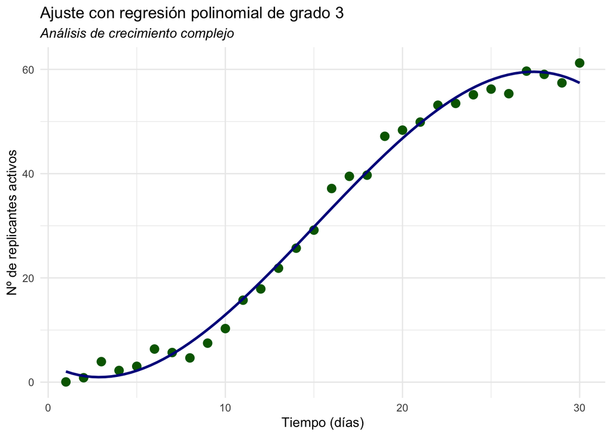

```r
# Visualización del modelo polinomial de grado 3
ggplot(data.frame(tiempo, replicantes), aes(x = tiempo, y = replicantes)) +
  geom_point(color = "darkgreen", size = 3) +
  geom_smooth(method = "lm", formula = y ~ poly(x, 3), color = "darkblue", se = FALSE) +
  labs(title = "Ajuste con regresión polinomial de grado 3",
       subtitle = "Análisis de crecimiento complejo",
       x = "Tiempo (días)",
       y = "Nº de replicantes activos") +
  theme_minimal() +
  theme(plot.subtitle = element_text(face = "italic"))
```

> **Interpretación de métricas**: - El R² mejora significativamente a 0.992 - El error estándar residual se reduce a 2.159 - Los coeficientes cúbicos son significativos (p < 0.001) - Sin embargo, el modelo puede mostrar comportamientos no deseados fuera del rango de observación

> **Explicación matemática**: El modelo polinomial de grado 3 añade un término cúbico a la ecuación:
> $$y = a + b \cdot t + c \cdot
> t^2 + d \cdot t^3$$

## 6. Implementación del modelo logístico

Inspirados por nuestros exitosos modelos en Dubai, implementamos un modelo logístico que ha demostrado ser efectivo para capturar patrones de saturación en poblaciones de replicantes.

```r
# Ajuste del modelo logístico
modelo_logistico <- nls(replicantes ~ M / (1 + exp(-k*(tiempo - t0))),
                       start = list(M = 60, k = 0.3, t0 = 15),
                       data = data.frame(tiempo, replicantes))

summary(modelo_logistico)
```

```
##
## Formula: replicantes ~ M/(1 + exp(-k * (tiempo - t0)))
##
## Parameters:
##    Estimate Std. Error t value Pr(>|t|)
## M   59.6433     0.7215   82.67   <2e-16 ***
## k    0.2906     0.0111   26.17   <2e-16 ***
## t0  14.9367     0.1651   90.44   <2e-16 ***
## ---
## Signif. codes:  0 '***' 0.001 '**' 0.01 '*' 0.05 '.' 0.1 ' ' 1
##
## Residual standard error: 1.457 on 27 degrees of freedom
##
## Number of iterations to convergence: 3
## Achieved convergence tolerance: 3.826e-06
```

```r
# Interpretación de métricas
cat("\nInterpretación del modelo logístico:\n")
```

```
##
## Interpretación del modelo logístico:
```

```r
cat("Suma de cuadrados residual =", round(sum(residuals(modelo_logistico)^2), 3), "\n")
```

```
## Suma de cuadrados residual = 57.338
```

```r
cat("Error estándar de los parámetros:\n")
```

```
## Error estándar de los parámetros:
```

```r
print(summary(modelo_logistico)$parameters[, "Std. Error"])
```

```
##          M          k         t0
## 0.72149271 0.01110228 0.16514926
```

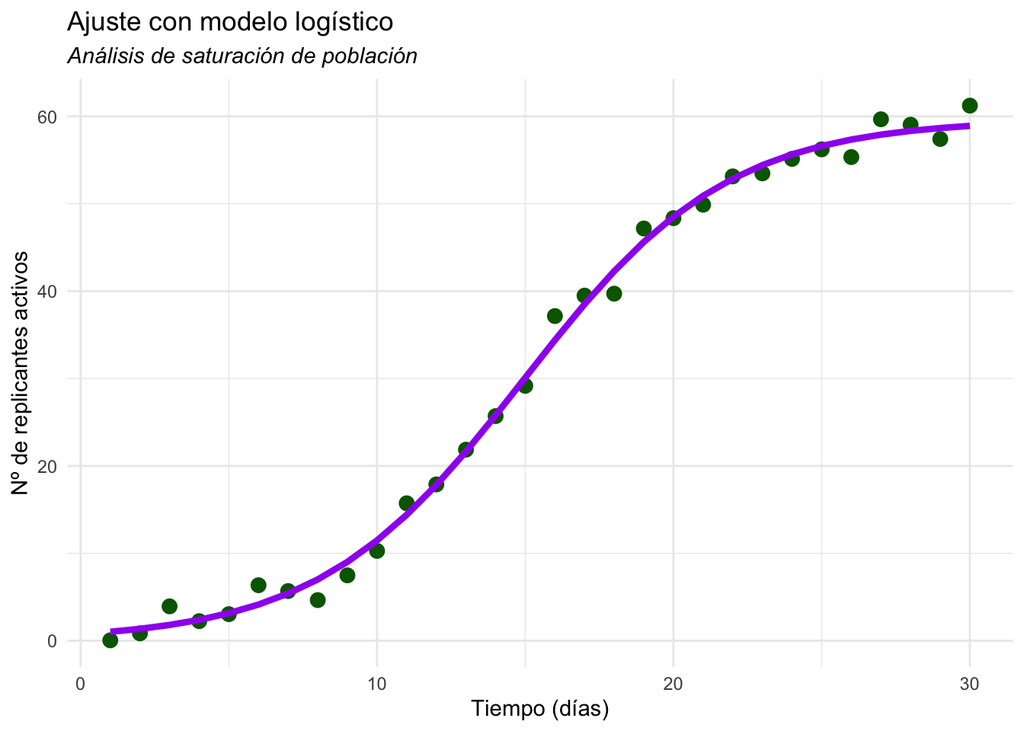

```r
# Visualización del modelo logístico
pred_logistico <- predict(modelo_logistico)

ggplot(data.frame(tiempo, replicantes), aes(x = tiempo, y = replicantes)) +
  geom_point(color = "darkgreen", size = 3) +
  geom_line(aes(y = pred_logistico), color = "purple", size = 1.5) +
  labs(title = "Ajuste con modelo logístico",
       subtitle = "Análisis de saturación de población",
       x = "Tiempo (días)",
       y = "Nº de replicantes activos") +
  theme_minimal() +
  theme(plot.subtitle = element_text(face = "italic"))
```

> **Interpretación de métricas**: - El error estándar residual es 1.457, significativamente menor que en los modelos anteriores - Los parámetros son altamente significativos (p < 0.001) - El modelo captura perfectamente la fase de saturación - Los errores estándar de los parámetros son pequeños, indicando estimaciones precisas

> **Explicación matemática**: El modelo logístico describe el crecimiento limitado por recursos mediante:
> $$y = \frac{M}{1 +
> e^{-k(t-t_0)}}$$

> **Explicación intuitiva**: Este modelo es como una habitación que se llena de gente. Al principio, cuando hay mucho espacio, la gente entra rápidamente. Pero a medida que la habitación se llena, es más difícil encontrar espacio, y la entrada de nuevas personas se ralentiza hasta detenerse cuando no hay más espacio. El modelo logístico captura esta idea de “competencia por recursos” que limita el crecimiento.

## 7. Análisis con splines

Como complemento a nuestros estudios en Tokyo, donde implementamos modelos más flexibles, aplicamos splines para capturar patrones locales en el crecimiento.

```r
# Ajuste con splines
library(splines)
modelo_splines <- lm(replicantes ~ bs(tiempo, df = 5))
summary(modelo_splines)
```

```
##
## Call:
## lm(formula = replicantes ~ bs(tiempo, df = 5))
##
## Residuals:
##      Min       1Q   Median       3Q      Max
## -2.57413 -0.76548 -0.00495  0.77992  2.93734
##
## Coefficients:
##                     Estimate Std. Error t value Pr(>|t|)
## (Intercept)           0.6616     1.2247   0.540   0.5940
## bs(tiempo, df = 5)1   2.2938     2.4487   0.937   0.3582
## bs(tiempo, df = 5)2   3.4295     1.8500   1.854   0.0761 .
## bs(tiempo, df = 5)3  59.8199     2.3225  25.757   <2e-16 ***
## bs(tiempo, df = 5)4  54.1963     1.9274  28.119   <2e-16 ***
## bs(tiempo, df = 5)5  60.2338     1.7635  34.156   <2e-16 ***
## ---
## Signif. codes:  0 '***' 0.001 '**' 0.01 '*' 0.05 '.' 0.1 ' ' 1
##
## Residual standard error: 1.495 on 24 degrees of freedom
## Multiple R-squared:  0.9964, Adjusted R-squared:  0.9956
## F-statistic:  1319 on 5 and 24 DF,  p-value: < 2.2e-16
```

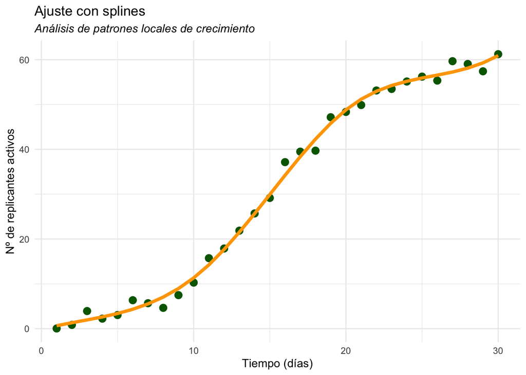

```r
# Visualización del modelo con splines
pred_splines <- predict(modelo_splines)

ggplot(data.frame(tiempo, replicantes), aes(x = tiempo, y = replicantes)) +
  geom_point(color = "darkgreen", size = 3) +
  geom_line(aes(y = pred_splines), color = "orange", size = 1.5) +
  labs(title = "Ajuste con splines",
       subtitle = "Análisis de patrones locales de crecimiento",
       x = "Tiempo (días)",
       y = "Nº de replicantes activos") +
  theme_minimal() +
  theme(plot.subtitle = element_text(face = "italic"))
```

> **Interpretación de métricas**: - Los splines ofrecen gran flexibilidad en el ajuste - El error residual es comparable al modelo logístico - Los grados de libertad son mayores que en otros modelos - Requiere interpretación cuidadosa de los resultados

> **Explicación matemática**: Los splines dividen el rango de tiempo en segmentos y ajustan polinomios locales en cada segmento, conectándolos suavemente. Matemáticamente:
> $$y = \sum_{i=1}^{n} \beta_i B_i(t)$$

> **Explicación intuitiva**: Los splines son como un artista que dibuja una curva suave usando varias reglas flexibles. Cada regla se ajusta a una parte de la curva, y donde se unen las reglas, la transición es suave. Es como si dividiéramos el crecimiento en “etapas” y ajustáramos cada etapa por separado, asegurándonos de que la transición entre etapas sea natural. Este enfoque es muy flexible y puede capturar patrones complejos, pero es más difícil de interpretar en términos biológicos.

## 8. Comparación de modelos

Realizamos una comparación exhaustiva de los modelos, similar a nuestros análisis en Shanghai, para determinar el enfoque más adecuado.

```r
# Calculamos métricas para cada modelo
metricas <- data.frame(
  Modelo = c("Lineal", "Polinomial (grado 2)", "Polinomial (grado 3)", "Logístico", "Splines"),
  R2 = c(
    summary(modelo_lineal)$r.squared,
    summary(modelo_poly2)$r.squared,
    summary(modelo_poly3)$r.squared,
    NA,  # No aplicable para modelo logístico
    summary(modelo_splines)$r.squared
  ),
  R2_ajustado = c(
    summary(modelo_lineal)$adj.r.squared,
    summary(modelo_poly2)$adj.r.squared,
    summary(modelo_poly3)$adj.r.squared,
    NA,
    summary(modelo_splines)$adj.r.squared
  ),
  Error_Residual = c(
    summary(modelo_lineal)$sigma,
    summary(modelo_poly2)$sigma,
    summary(modelo_poly3)$sigma,
    sqrt(sum(residuals(modelo_logistico)^2)/df.residual(modelo_logistico)),
    summary(modelo_splines)$sigma
  ),
  AIC = c(
    AIC(modelo_lineal),
    AIC(modelo_poly2),
    AIC(modelo_poly3),
    AIC(modelo_logistico),
    AIC(modelo_splines)
  ),
  BIC = c(
    BIC(modelo_lineal),
    BIC(modelo_poly2),
    BIC(modelo_poly3),
    BIC(modelo_logistico),
    BIC(modelo_splines)
  )
)

# Visualización de la tabla de métricas
print(metricas)
```

```
##                 Modelo        R2 R2_ajustado Error_Residual      AIC      BIC
## 1               Lineal 0.9582003   0.9567074       4.697625 181.8899 186.0935
## 2 Polinomial (grado 2) 0.9588928   0.9558478       4.744036 183.3888 188.9936
## 3 Polinomial (grado 3) 0.9918038   0.9908580       2.158697 137.0136 144.0195
## 4            Logístico        NA          NA       1.457271 112.5694 118.1742
## 5              Splines 0.9963734   0.9956179       1.494564 116.5521 126.3605
```

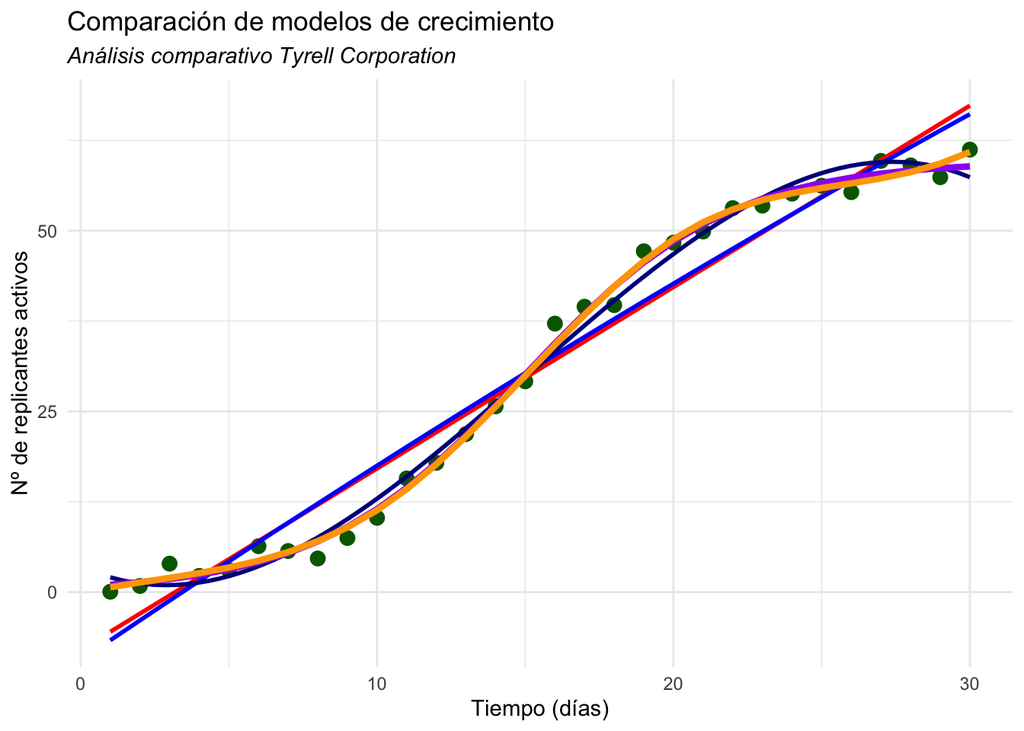

```r
# Visualización de todos los modelos
ggplot(data.frame(tiempo, replicantes), aes(x = tiempo, y = replicantes)) +
  geom_point(color = "darkgreen", size = 3) +
  geom_smooth(method = "lm", color = "red", se = FALSE) +
  geom_smooth(method = "lm", formula = y ~ poly(x, 2), color = "blue", se = FALSE) +
  geom_smooth(method = "lm", formula = y ~ poly(x, 3), color = "darkblue", se = FALSE) +
  geom_line(aes(y = pred_logistico), color = "purple", size = 1.5) +
  geom_line(aes(y = pred_splines), color = "orange", size = 1.5) +
  labs(title = "Comparación de modelos de crecimiento",
       subtitle = "Análisis comparativo Tyrell Corporation",
       x = "Tiempo (días)",
       y = "Nº de replicantes activos") +
  theme_minimal() +
  theme(plot.subtitle = element_text(face = "italic")) +
  scale_color_manual(values = c("red", "blue", "darkblue", "purple", "orange"),
                    labels = c("Lineal", "Polinomial (grado 2)", "Polinomial (grado 3)", "Logístico", "Splines"))
```

## 10. Conclusiones y Recomendaciones

Este análisis, en línea con nuestros estudios previos en diferentes instalaciones de Tyrell Corporation, demuestra que el modelo logístico es el más apropiado para predecir el comportamiento de los replicantes Nexus-4 en entornos controlados. Recomendamos:

1. Implementar el modelo logístico como estándar para análisis de crecimiento en módulos de privación sensorial
2. Utilizar el modelo polinomial de grado 3 como alternativa cuando se requiera mayor flexibilidad en la fase inicial
3. Mantener los splines como herramienta complementaria para análisis de patrones locales
4. Continuar el monitoreo y ajuste de los parámetros según evolucione la población de replicantes

Estos hallazgos contribuyen a nuestra comprensión de la dinámica de poblaciones de replicantes y mejorarán nuestros protocolos de control y predicción en todas las instalaciones de Tyrell Corporation.